# OLS model

12/2/2020

```r
library(tidyverse)
library(lubridate)
library(haven)
library(dplyr)
library(ggplot2)
library(ggthemes)
library(readr)
library(kableExtra)
library(jtools)
library(huxtable)
library(stargazer)
```

## Loading the data

```r
clean_df <- read_csv("clean_df.csv", col_types = cols(date = col_date(format = "%Y-%m-%d")))
clean_df$state <- as.factor(clean_df$state)
```

## Doing some wrangling on “cases”

```r
# Creating a 'cases per 1000 ppl' indicator
clean_df <- clean_df %>%
  mutate(cases_per_1000ppl = ((clean_df$cases / clean_df$total_population) * 1000))

head(clean_df)
```

| X1 | OBJECTID | total_pop_worked_home | percent_no_health_insurance | GEOID | NAME | State | avg_household_size | pop_density_sq_km | percent_below_poverty_level | total_population | total_households_w_someone_over_65 | total_over_65 | White | Black | American_Indian_Alaska_Native | Asian | Native_Hawaiian_Pacific_Islander | Other | Two_or_more | Not_Hispanic_Latino | Hispanic_Latino | date | county | state | cases | deaths | confirmed_cases | confirmed_deaths | probable_cases | … |
| --- | --- | --- | --- | --- | --- | --- | --- | --- | --- | --- | --- | --- | --- | --- | --- | --- | --- | --- | --- | --- | --- | --- | --- | --- | --- | --- | --- | --- | --- | --- |
| 1 | 1 | 675 | 7.1 | 01001 | Autauga County | Alabama | 2.59 | 35.9 | 15 | 5.52e+04 | 5.73e+03 | 8.05e+03 | 4.24e+04 | 1.06e+04 | 159 | 568 | 32 | 409 | 1.03e+03 | 5.37e+04 | 1.53e+03 | 2020-11-30 | Autauga | Alabama | 2.75e+03 | 42 | 2.46e+03 | 37 | 292 | … |
| 2 | 2 | 5.61e+03 | 10.2 | 01003 | Baldwin County | Alabama | 2.61 | 50.5 | 11 | 2.08e+05 | 2.75e+04 | 4.07e+04 | 1.8e+05 | 1.98e+04 | 1.52e+03 | 1.68e+03 | 9 | 2.03e+03 | 3.57e+03 | 1.99e+05 | 9.35e+03 | 2020-11-30 | Baldwin | Alabama | 8.82e+03 | 98 | 7.15e+03 | 84 | 1.67e+03 | … |
| 3 | 3 | 111 | 11.2 | 01005 | Barbour County | Alabama | 2.49 | 11.2 | 25.9 | 2.58e+04 | 3.32e+03 | 4.63e+03 | 1.22e+04 | 1.23e+04 | 72 | 96 | 1 | 778 | 353 | 2.47e+04 | 1.11e+03 | 2020-11-30 | Barbour | Alabama | 1.18e+03 | 11 | 781 | 11 | 394 | … |
| 4 | 4 | 208 | 7.9 | 01007 | Bibb County | Alabama | 2.99 | 14 | 14.2 | 2.25e+04 | 2.42e+03 | 3.66e+03 | 1.73e+04 | 5.02e+03 | 8 | 37 | 0 | 9 | 187 | 2.2e+04 | 547 | 2020-11-30 | Bibb | Alabama | 1.19e+03 | 17 | 1.07e+03 | 13 | 116 | … |
| 5 | 5 | 477 | 11 | 01009 | Blount County | Alabama | 2.77 | 34.5 | 14.3 | 5.76e+04 | 6.66e+03 | 1.02e+04 | 5.51e+04 | 862 | 141 | 198 | 18 | 437 | 935 | 5.24e+04 | 5.26e+03 | 2020-11-30 | Blount | Alabama | 2.95e+03 | 40 | 2.21e+03 | 38 | 733 | … |
| 6 | 6 | 108 | 10.8 | 01011 | Bullock County | Alabama | 2.75 | 6.42 | 33.7 | 1.04e+04 | 1.06e+03 | 1.62e+03 | 2.28e+03 | 7.89e+03 | 122 | 56 | 0 | 5 | 0 | 1.03e+04 | 51 | 2020-11-30 | Bullock | Alabama | 700 | 19 | 650 | 15 | 50 | … |

```r
# There are some observations that report "cases per 1000 ppl" > 1000. For the purposes of our analyses, we will drop these observations.
clean_df <- clean_df %>%
  filter(cases_per_1000ppl < 1000)

# We dropped 120 observations
```

## Descriptive statistics

Before devising OLS model(s), we decided to explore potential associations derived from visualizations.

#Question 1 The epidemiology of the COVID-19 respiratory syndrome suggests that more densely populated counties are more prone to spreading the virus given the airborne nature of the infection. Is this consistent with the data?

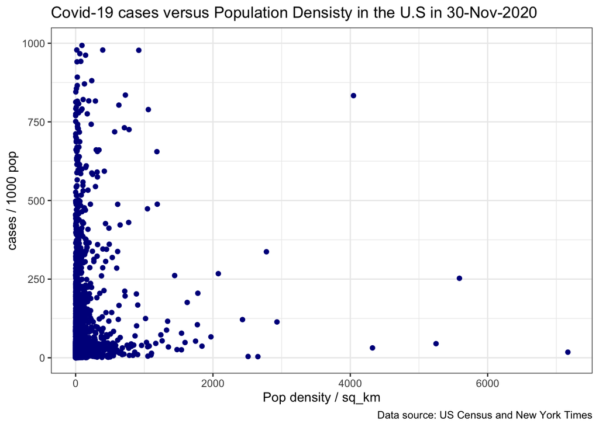

DISCUSSION: Graphically, we cannot see a strong association between Cases / 1000 population and Population density.

#Question 2 Continuing to explore the relationship between social distancing and cases, we could hypothesize that more people working from home is associated with less cases. Is this consistent with the data?

[output not shown]

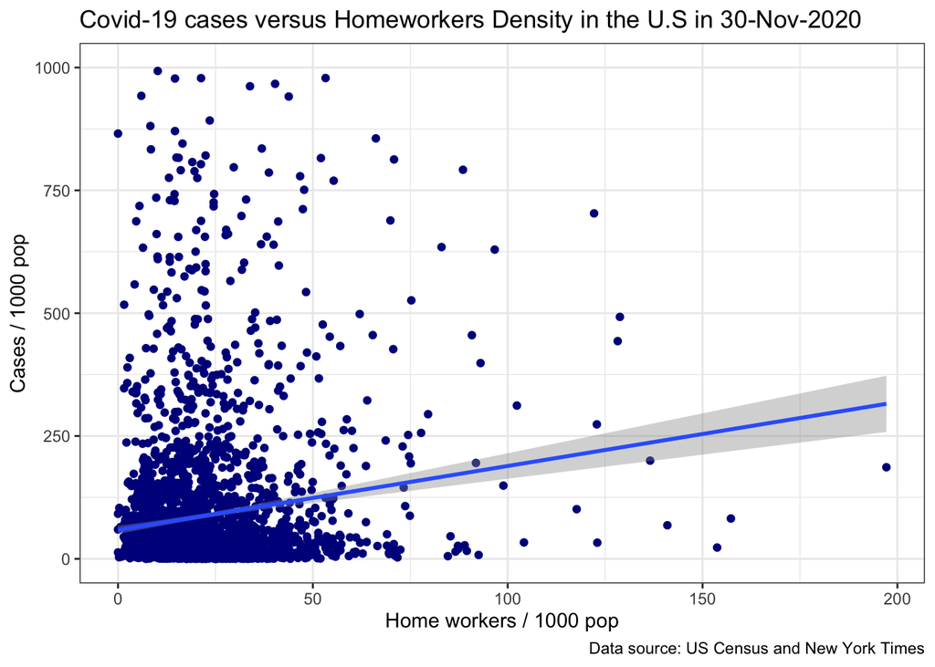

DISCUSSION: Graphically, it seems that this relationship should be explored with an OLS,controlled for other covariates. The plot suggests that ‘cases / 1000 pop’ is positively associated with ‘home workers / 1000 pop’, which is very counter-intuitive.

#Question 3 Following the ‘standard’ protocols for COVID-19 prevention, our third graphical analysis explores the association between mask wearing and Covid-19 incidence.

[output not shown]

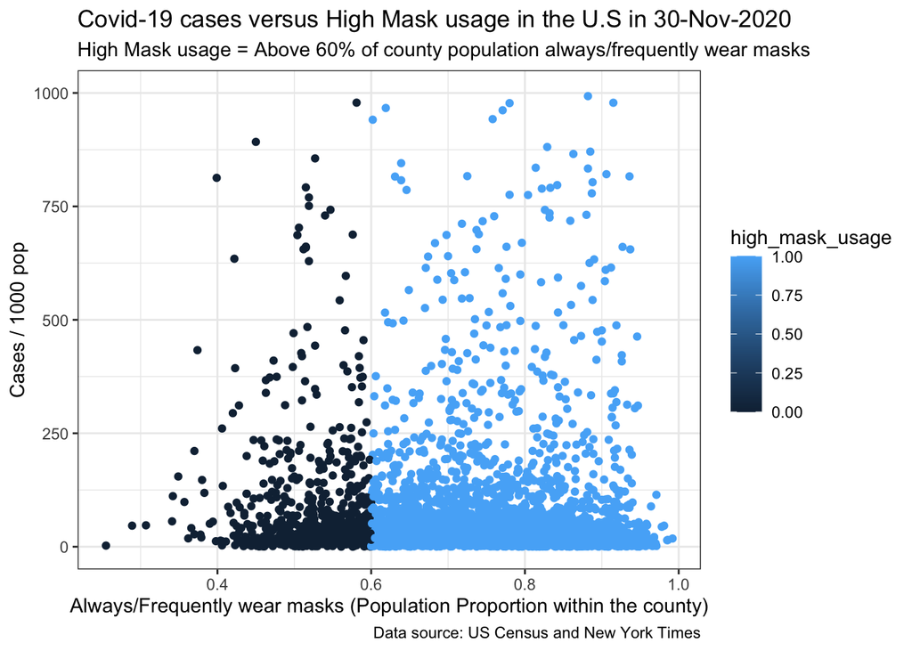

DISCUSSION: Although we observe more counties fall above the 0.60 high mask usage threshold, we cannot observe a systematically different association between high mask usage and Case/1000 pop (considering just the graphical analysis).

# OLS model assessing Questions 1, 2, and 3

Can we explain the variation in Cases/pop by population density, working from home, and mask - wearing?

| Observations | 3013 (77 missing obs. deleted) |
| --- | --- |
| Dependent variable | cases_per_1000ppl |
| Type | OLS linear regression |

| F(3,3009) | 31.45 |
| --- | --- |
| R² | 0.03 |
| Adj. R² | 0.03 |

|  | Est. | S.E. | t val. | p |
| --- | --- | --- | --- | --- |
| (Intercept) | 63.13 | 7.21 | 8.75 | 0.00 |
| homeoffice_per_1000ppl | 1.21 | 0.17 | 7.07 | 0.00 |
| pop_density_sq_km | 0.06 | 0.01 | 6.25 | 0.00 |
| high_mask_usage | -7.05 | 6.43 | -1.10 | 0.27 |

Standard errors: OLS

DISCUSSION: Using just the 3 covariates explored in Q1, Q2, and Q3, we cannot see statistical significance in high-mask-usage. A marginal change in population density is associated with a mean increase of .06 in cases/1000 ppl (p<0.00) and, counter-intuitively, a marginal change in homeoffice workers / 1000ppl is associated with a mean increase of 1.21 cases (p<0.00).

#Question 4 It is reasonable to assume that there are some Omitted Variable Bias in coefficient(s) from Model 1. Intuitively (and from the media coverage), we know that low-income workers are less likely to work from home. Let’s include population % below the poverty line and see how the model ‘responds’.

| Observations | 3013 (77 missing obs. deleted) |
| --- | --- |
| Dependent variable | cases_per_1000ppl |
| Type | OLS linear regression |

| F(4,3008) | 29.50 |
| --- | --- |
| R² | 0.04 |
| Adj. R² | 0.04 |

|  | Est. | S.E. | t val. | p |
| --- | --- | --- | --- | --- |
| (Intercept) | 22.94 | 11.05 | 2.08 | 0.04 |
| homeoffice_per_1000ppl | 1.55 | 0.18 | 8.40 | 0.00 |
| pop_density_sq_km | 0.06 | 0.01 | 6.57 | 0.00 |
| high_mask_usage | -7.70 | 6.41 | -1.20 | 0.23 |
| percent_below_poverty_level | 2.16 | 0.45 | 4.79 | 0.00 |

Standard errors: OLS

DISCUSSION: Indeed, part of the variation in cases is explained by the poverty level. One percentage point increase in the county population below poverty level is associated with a mean increase of 2.16 cases/1000 ppl (p<0.00).

#Question 5 Since health regulations (and the epidemic response, in general) varies a lot across states, we could try to control by state to see how much of the Case variation is explained by the state. We also could see if the other coefficients would change in sign and/or magnitude.

| Observations | 3013 (77 missing obs. deleted) |
| --- | --- |
| Dependent variable | cases_per_1000ppl |
| Type | OLS linear regression |

| F(54,2958) | 6.04 |
| --- | --- |
| R² | 0.10 |
| Adj. R² | 0.08 |

|  | Est. | S.E. | t val. | p |
| --- | --- | --- | --- | --- |
| (Intercept) | -47.60 | 20.95 | -2.27 | 0.02 |
| homeoffice_per_1000ppl | 1.45 | 0.21 | 6.89 | 0.00 |
| pop_density_sq_km | 0.09 | 0.01 | 9.00 | 0.00 |
| high_mask_usage | 26.16 | 7.51 | 3.48 | 0.00 |
| percent_below_poverty_level | 2.94 | 0.50 | 5.91 | 0.00 |
| stateAlaska | -25.70 | 31.45 | -0.82 | 0.41 |
| stateArizona | -9.12 | 39.01 | -0.23 | 0.82 |
| stateArkansas | -0.58 | 22.94 | -0.03 | 0.98 |
| stateCalifornia | -58.26 | 24.97 | -2.33 | 0.02 |
| stateColorado | -45.09 | 24.70 | -1.83 | 0.07 |
| stateConnecticut | -42.82 | 51.39 | -0.83 | 0.40 |
| stateDelaware | -29.12 | 80.64 | -0.36 | 0.72 |
| stateDistrict of Columbia | -425.43 | 143.85 | -2.96 | 0.00 |
| stateFlorida | -14.64 | 23.75 | -0.62 | 0.54 |
| stateGeorgia | -15.86 | 19.90 | -0.80 | 0.43 |
| stateHawaii | -65.08 | 70.40 | -0.92 | 0.36 |
| stateIdaho | 76.42 | 27.51 | 2.78 | 0.01 |
| stateIllinois | 73.95 | 21.88 | 3.38 | 0.00 |
| stateIndiana | 78.33 | 22.25 | 3.52 | 0.00 |
| stateIowa | 83.45 | 22.37 | 3.73 | 0.00 |
| stateKansas | 69.55 | 22.24 | 3.13 | 0.00 |
| stateKentucky | 17.11 | 20.87 | 0.82 | 0.41 |
| stateLouisiana | 39.64 | 24.15 | 1.64 | 0.10 |
| stateMaine | -43.67 | 38.17 | -1.14 | 0.25 |
| stateMaryland | 32.33 | 33.02 | 0.98 | 0.33 |
| stateMassachusetts | -49.18 | 45.09 | -1.09 | 0.28 |
| stateMichigan | 23.26 | 22.95 | 1.01 | 0.31 |
| stateMinnesota | 85.60 | 23.28 | 3.68 | 0.00 |
| stateMississippi | 34.74 | 22.53 | 1.54 | 0.12 |
| stateMissouri | 54.62 | 21.54 | 2.54 | 0.01 |
| stateMontana | 89.83 | 26.63 | 3.37 | 0.00 |
| stateNebraska | 64.31 | 23.27 | 2.76 | 0.01 |
| stateNevada | 4.92 | 40.27 | 0.12 | 0.90 |
| stateNew Hampshire | -39.14 | 46.62 | -0.84 | 0.40 |
| stateNew Jersey | -36.35 | 35.44 | -1.03 | 0.31 |
| stateNew Mexico | 29.15 | 30.42 | 0.96 | 0.34 |
| stateNew York | 3.44 | 25.00 | 0.14 | 0.89 |
| stateNorth Carolina | 29.25 | 21.75 | 1.34 | 0.18 |
| stateNorth Dakota | 88.58 | 27.35 | 3.24 | 0.00 |
| stateOhio | 33.47 | 22.51 | 1.49 | 0.14 |
| stateOklahoma | 63.82 | 23.16 | 2.76 | 0.01 |
| stateOregon | 30.41 | 28.78 | 1.06 | 0.29 |
| statePennsylvania | 32.06 | 24.11 | 1.33 | 0.18 |
| stateRhode Island | 0.29 | 63.46 | 0.00 | 1.00 |
| stateSouth Carolina | 51.37 | 26.67 | 1.93 | 0.05 |
| stateSouth Dakota | 88.99 | 25.02 | 3.56 | 0.00 |
| stateTennessee | 37.94 | 22.12 | 1.72 | 0.09 |
| stateTexas | 37.83 | 19.16 | 1.97 | 0.05 |
| stateUtah | 53.26 | 31.93 | 1.67 | 0.10 |
| stateVermont | -60.06 | 40.52 | -1.48 | 0.14 |
| stateVirginia | -10.53 | 21.09 | -0.50 | 0.62 |
| stateWashington | 18.15 | 27.80 | 0.65 | 0.51 |
| stateWest Virginia | -1.02 | 24.85 | -0.04 | 0.97 |
| stateWisconsin | 68.91 | 24.06 | 2.86 | 0.00 |
| stateWyoming | 56.16 | 33.45 | 1.68 | 0.09 |

Standard errors: OLS

## Comparing Models 1, 2, and 3

|  | Model 1 | Model 2 | Model 3 |
| --- | --- | --- | --- |
| (Intercept) | 63.13 *** | 22.94 * | -47.60 * |
|  | (7.21) | (11.05) | (20.95) |
| homeoffice_per_1000ppl | 1.21 *** | 1.55 *** | 1.45 *** |
|  | (0.17) | (0.18) | (0.21) |
| pop_density_sq_km | 0.06 *** | 0.06 *** | 0.09 *** |
|  | (0.01) | (0.01) | (0.01) |
| high_mask_usage | -7.05 | -7.70 | 26.16 *** |
|  | (6.43) | (6.41) | (7.51) |
| percent_below_poverty_level |  | 2.16 *** | 2.94 *** |
|  |  | (0.45) | (0.50) |
| stateAlaska |  |  | -25.70 |
|  |  |  | (31.45) |
| stateArizona |  |  | -9.12 |
|  |  |  | (39.01) |
| stateArkansas |  |  | -0.58 |
|  |  |  | (22.94) |
| stateCalifornia |  |  | -58.26 * |
|  |  |  | (24.97) |
| stateColorado |  |  | -45.09 |
|  |  |  | (24.70) |
| stateConnecticut |  |  | -42.82 |
|  |  |  | (51.39) |
| stateDelaware |  |  | -29.12 |
|  |  |  | (80.64) |
| stateDistrict of Columbia |  |  | -425.43 ** |
|  |  |  | (143.85) |
| stateFlorida |  |  | -14.64 |
|  |  |  | (23.75) |
| stateGeorgia |  |  | -15.86 |
|  |  |  | (19.90) |

[output cut: 83 more lines]

# Exploring another issue: Racial inequality

#Question 6 Is there a systematic difference in the distribution cases/1000 ppl depending on the counties’ predominant ethnic group? More specifically, being predominantly white / non-white is associated helps explain the variability in cases across counties?

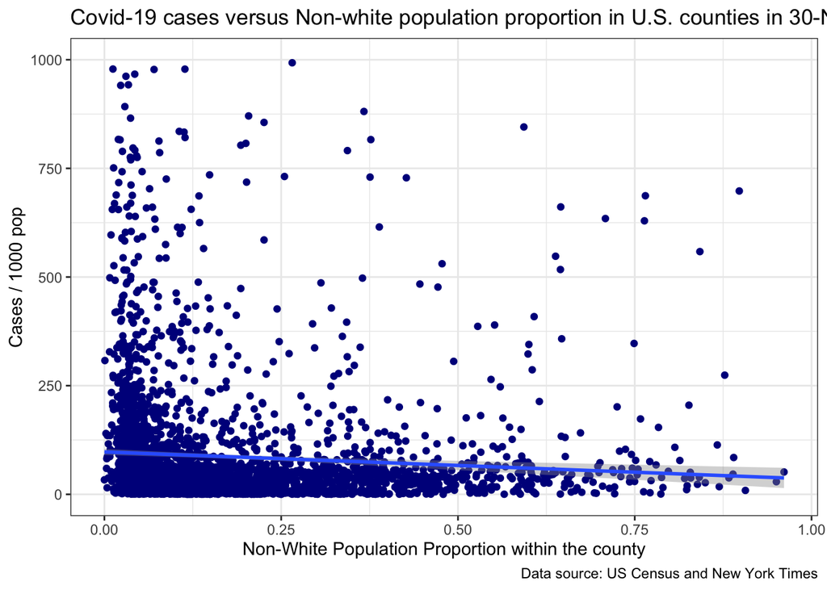

DISCUSSION: Graphically, the association between Cases/1000 pop does not seem very strong. Let’s see how an OLS model capture this relationship.

| Observations | 3090 |
| --- | --- |
| Dependent variable | cases_per_1000ppl |
| Type | OLS linear regression |

| F(52,3037) | 3.25 |
| --- | --- |
| R² | 0.05 |
| Adj. R² | 0.04 |

|  | Est. | S.E. | t val. | p |
| --- | --- | --- | --- | --- |
| (Intercept) | 61.33 | 18.06 | 3.40 | 0.00 |
| non_white_proportion | -25.93 | 19.12 | -1.36 | 0.18 |
| as.factor(state)Alaska | -19.26 | 31.72 | -0.61 | 0.54 |
| as.factor(state)Arizona | -3.93 | 39.59 | -0.10 | 0.92 |
| as.factor(state)Arkansas | -3.21 | 23.38 | -0.14 | 0.89 |
| as.factor(state)California | -27.61 | 24.88 | -1.11 | 0.27 |
| as.factor(state)Colorado | -23.28 | 24.63 | -0.95 | 0.34 |
| as.factor(state)Connecticut | -30.42 | 51.89 | -0.59 | 0.56 |
| as.factor(state)Delaware | -16.71 | 81.74 | -0.20 | 0.84 |
| as.factor(state)District of Columbia | -14.69 | 139.62 | -0.11 | 0.92 |
| as.factor(state)Florida | -4.94 | 24.04 | -0.21 | 0.84 |
| as.factor(state)Georgia | -5.06 | 20.17 | -0.25 | 0.80 |
| as.factor(state)Hawaii | -40.56 | 71.41 | -0.57 | 0.57 |
| as.factor(state)Idaho | 60.93 | 27.87 | 2.19 | 0.03 |
| as.factor(state)Illinois | 61.58 | 22.35 | 2.75 | 0.01 |
| as.factor(state)Indiana | 59.11 | 22.80 | 2.59 | 0.01 |
| as.factor(state)Iowa | 64.64 | 22.62 | 2.86 | 0.00 |
| as.factor(state)Kansas | 51.64 | 22.47 | 2.30 | 0.02 |
| as.factor(state)Kentucky | 15.98 | 21.76 | 0.73 | 0.46 |
| as.factor(state)Louisiana | 45.51 | 24.52 | 1.86 | 0.06 |
| as.factor(state)Maine | -41.92 | 38.91 | -1.08 | 0.28 |
| as.factor(state)Maryland | 48.74 | 32.96 | 1.48 | 0.14 |
| as.factor(state)Massachusetts | 8.18 | 45.14 | 0.18 | 0.86 |
| as.factor(state)Michigan | 14.73 | 23.49 | 0.63 | 0.53 |
| as.factor(state)Minnesota | 71.48 | 23.19 | 3.08 | 0.00 |
| as.factor(state)Mississippi | 45.88 | 22.91 | 2.00 | 0.05 |
| as.factor(state)Missouri | 40.60 | 21.97 | 1.85 | 0.06 |
| as.factor(state)Montana | 92.16 | 25.90 | 3.56 | 0.00 |
| as.factor(state)Nebraska | 70.17 | 22.95 | 3.06 | 0.00 |
| as.factor(state)Nevada | -8.76 | 40.82 | -0.21 | 0.83 |
| as.factor(state)New Hampshire | -40.70 | 47.18 | -0.86 | 0.39 |
| as.factor(state)New Jersey | 27.52 | 34.66 | 0.79 | 0.43 |
| as.factor(state)New Mexico | 39.43 | 30.50 | 1.29 | 0.20 |
| as.factor(state)New York | 3.88 | 25.31 | 0.15 | 0.88 |
| as.factor(state)North Carolina | 35.71 | 21.98 | 1.62 | 0.10 |
| as.factor(state)North Dakota | 75.05 | 26.50 | 2.83 | 0.00 |
| as.factor(state)Ohio | 17.80 | 23.03 | 0.77 | 0.44 |
| as.factor(state)Oklahoma | 49.92 | 23.35 | 2.14 | 0.03 |
| as.factor(state)Oregon | 36.03 | 29.19 | 1.23 | 0.22 |
| as.factor(state)Pennsylvania | 25.91 | 24.53 | 1.06 | 0.29 |
| as.factor(state)Puerto Rico | -12.38 | 23.21 | -0.53 | 0.59 |
| as.factor(state)Rhode Island | 32.33 | 64.29 | 0.50 | 0.62 |
| as.factor(state)South Carolina | 57.36 | 27.10 | 2.12 | 0.03 |
| as.factor(state)South Dakota | 100.09 | 24.47 | 4.09 | 0.00 |
| as.factor(state)Tennessee | 26.50 | 22.72 | 1.17 | 0.24 |
| as.factor(state)Texas | 29.67 | 19.55 | 1.52 | 0.13 |
| as.factor(state)Utah | 44.68 | 32.32 | 1.38 | 0.17 |
| as.factor(state)Vermont | -51.53 | 40.99 | -1.26 | 0.21 |
| as.factor(state)Virginia | 10.46 | 20.98 | 0.50 | 0.62 |
| as.factor(state)Washington | 22.84 | 28.09 | 0.81 | 0.42 |
| as.factor(state)West Virginia | -10.21 | 25.77 | -0.40 | 0.69 |
| as.factor(state)Wisconsin | 56.63 | 24.38 | 2.32 | 0.02 |
| as.factor(state)Wyoming | 43.60 | 33.79 | 1.29 | 0.20 |

Standard errors: OLS

DISCUSSION: In this model, non-white District population proportion does not explain the variability in cases. We had to control the model from state dummy variables because, as we have seen from previous models, state-wide factors (possibly policies, such as lockdowns and other health regulations) are statistically significant in explaining the variability in cases (p<0.00).

#Question 7 What about the variability in deaths? Does non-white county population proportion help explain the variability in deaths by covid-19?

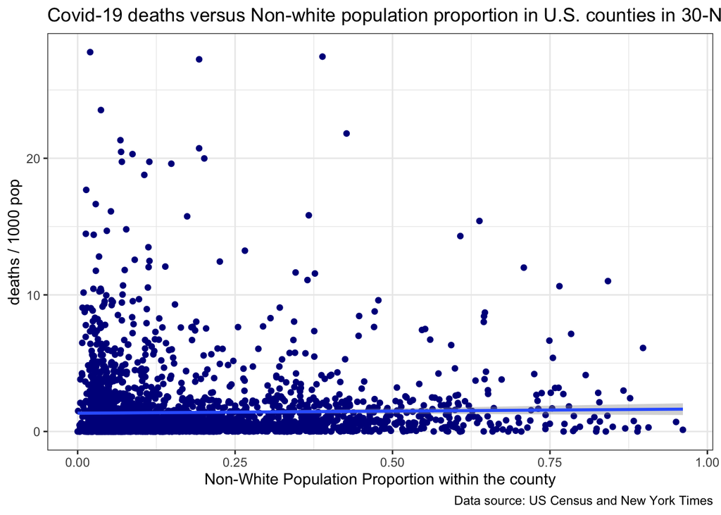

DISCUSSION: Once again, the relationship does not seem very strong (at least, not graphically). Let’s explore the relationship between death/1000 pop and Non-white county population proportion with an OLS model, controlling for state-wide factors.

| Observations | 3014 (76 missing obs. deleted) |
| --- | --- |
| Dependent variable | deaths_per_1000ppl |
| Type | OLS linear regression |

| F(51,2962) | 3.99 |
| --- | --- |
| R² | 0.06 |
| Adj. R² | 0.05 |

|  | Est. | S.E. | t val. | p |
| --- | --- | --- | --- | --- |
| (Intercept) | 1.07 | 0.32 | 3.35 | 0.00 |
| non_white_proportion | -0.39 | 0.35 | -1.12 | 0.26 |
| as.factor(state)Alaska | -0.79 | 0.56 | -1.41 | 0.16 |
| as.factor(state)Arizona | 0.25 | 0.70 | 0.36 | 0.72 |
| as.factor(state)Arkansas | -0.06 | 0.41 | -0.14 | 0.89 |
| as.factor(state)California | -0.64 | 0.44 | -1.46 | 0.14 |
| as.factor(state)Colorado | -0.65 | 0.44 | -1.50 | 0.13 |
| as.factor(state)Connecticut | 0.03 | 0.92 | 0.04 | 0.97 |
| as.factor(state)Delaware | -0.09 | 1.44 | -0.06 | 0.95 |
| as.factor(state)District of Columbia | 0.15 | 2.47 | 0.06 | 0.95 |
| as.factor(state)Florida | -0.03 | 0.42 | -0.06 | 0.95 |
| as.factor(state)Georgia | 0.41 | 0.36 | 1.14 | 0.25 |
| as.factor(state)Hawaii | -0.76 | 1.26 | -0.60 | 0.55 |
| as.factor(state)Idaho | 0.04 | 0.49 | 0.09 | 0.93 |
| as.factor(state)Illinois | 0.71 | 0.40 | 1.80 | 0.07 |
| as.factor(state)Indiana | 0.87 | 0.40 | 2.17 | 0.03 |
| as.factor(state)Iowa | 0.29 | 0.40 | 0.73 | 0.46 |
| as.factor(state)Kansas | 0.08 | 0.40 | 0.19 | 0.85 |
| as.factor(state)Kentucky | -0.21 | 0.38 | -0.54 | 0.59 |
| as.factor(state)Louisiana | 1.67 | 0.43 | 3.85 | 0.00 |
| as.factor(state)Maine | -0.74 | 0.69 | -1.07 | 0.28 |
| as.factor(state)Maryland | 1.32 | 0.58 | 2.27 | 0.02 |
| as.factor(state)Massachusetts | 1.99 | 0.80 | 2.50 | 0.01 |
| as.factor(state)Michigan | 0.15 | 0.42 | 0.37 | 0.71 |
| as.factor(state)Minnesota | 0.13 | 0.41 | 0.32 | 0.75 |
| as.factor(state)Mississippi | 1.67 | 0.40 | 4.12 | 0.00 |
| as.factor(state)Missouri | 0.08 | 0.39 | 0.20 | 0.84 |
| as.factor(state)Montana | 0.86 | 0.46 | 1.87 | 0.06 |
| as.factor(state)Nebraska | 0.11 | 0.41 | 0.27 | 0.78 |
| as.factor(state)Nevada | -0.31 | 0.72 | -0.43 | 0.66 |
| as.factor(state)New Hampshire | -0.63 | 0.83 | -0.76 | 0.45 |
| as.factor(state)New Jersey | 3.00 | 0.61 | 4.91 | 0.00 |
| as.factor(state)New Mexico | 0.29 | 0.54 | 0.54 | 0.59 |
| as.factor(state)New York | 0.66 | 0.45 | 1.49 | 0.14 |
| as.factor(state)North Carolina | 0.29 | 0.39 | 0.75 | 0.45 |
| as.factor(state)North Dakota | 1.41 | 0.47 | 3.00 | 0.00 |
| as.factor(state)Ohio | 0.15 | 0.41 | 0.36 | 0.72 |
| as.factor(state)Oklahoma | 0.05 | 0.41 | 0.13 | 0.90 |
| as.factor(state)Oregon | 0.25 | 0.52 | 0.48 | 0.63 |
| as.factor(state)Pennsylvania | 0.96 | 0.43 | 2.23 | 0.03 |
| as.factor(state)Rhode Island | 1.67 | 1.14 | 1.47 | 0.14 |
| as.factor(state)South Carolina | 1.35 | 0.48 | 2.81 | 0.00 |
| as.factor(state)South Dakota | 1.38 | 0.43 | 3.18 | 0.00 |
| as.factor(state)Tennessee | 0.20 | 0.40 | 0.50 | 0.62 |
| as.factor(state)Texas | 1.15 | 0.35 | 3.33 | 0.00 |
| as.factor(state)Utah | -0.47 | 0.57 | -0.82 | 0.41 |
| as.factor(state)Vermont | -0.93 | 0.72 | -1.29 | 0.20 |
| as.factor(state)Virginia | 0.04 | 0.37 | 0.12 | 0.91 |
| as.factor(state)Washington | 0.24 | 0.50 | 0.48 | 0.63 |
| as.factor(state)West Virginia | -0.32 | 0.46 | -0.71 | 0.48 |
| as.factor(state)Wisconsin | -0.07 | 0.43 | -0.16 | 0.87 |
| as.factor(state)Wyoming | -0.25 | 0.60 | -0.42 | 0.67 |

Standard errors: OLS

DISCUSSION: As we had anticipated, non-white population proportion does not explain thew variability in deaths/1000 population at the county level.

Intuitively, health insurance coverage might increase access to health care, potentially affecting deaths by covid-19. In the next models, we will include insurance coverage and poverty line (as a proxy for the ability to cover out-of-pocket health expenditures) in our model.

| Observations | 3007 (83 missing obs. deleted) |
| --- | --- |
| Dependent variable | deaths_per_1000ppl |
| Type | OLS linear regression |

| F(53,2953) | 4.23 |
| --- | --- |
| R² | 0.07 |
| Adj. R² | 0.05 |

|  | Est. | S.E. | t val. | p |
| --- | --- | --- | --- | --- |
| (Intercept) | 0.41 | 0.35 | 1.17 | 0.24 |
| non_white_proportion | -1.07 | 0.38 | -2.82 | 0.00 |
| as.factor(state)Alaska | -0.41 | 0.59 | -0.69 | 0.49 |
| as.factor(state)Arizona | 0.28 | 0.70 | 0.40 | 0.69 |
| as.factor(state)Arkansas | -0.09 | 0.41 | -0.21 | 0.83 |
| as.factor(state)California | -0.40 | 0.44 | -0.91 | 0.36 |
| as.factor(state)Colorado | -0.51 | 0.44 | -1.17 | 0.24 |
| as.factor(state)Connecticut | 0.41 | 0.92 | 0.45 | 0.65 |
| as.factor(state)Delaware | 0.27 | 1.44 | 0.19 | 0.85 |
| as.factor(state)District of Columbia | 0.57 | 2.46 | 0.23 | 0.82 |
| as.factor(state)Florida | 0.07 | 0.43 | 0.16 | 0.87 |
| as.factor(state)Georgia | 0.42 | 0.36 | 1.18 | 0.24 |
| as.factor(state)Hawaii | -0.22 | 1.26 | -0.18 | 0.86 |
| as.factor(state)Idaho | 0.10 | 0.50 | 0.20 | 0.84 |
| as.factor(state)Illinois | 0.88 | 0.40 | 2.21 | 0.03 |
| as.factor(state)Indiana | 1.03 | 0.40 | 2.55 | 0.01 |
| as.factor(state)Iowa | 0.51 | 0.40 | 1.26 | 0.21 |
| as.factor(state)Kansas | 0.23 | 0.40 | 0.58 | 0.56 |
| as.factor(state)Kentucky | -0.37 | 0.39 | -0.96 | 0.34 |
| as.factor(state)Louisiana | 1.67 | 0.43 | 3.85 | 0.00 |
| as.factor(state)Maine | -0.66 | 0.69 | -0.97 | 0.33 |
| as.factor(state)Maryland | 1.76 | 0.59 | 2.99 | 0.00 |
| as.factor(state)Massachusetts | 2.29 | 0.80 | 2.86 | 0.00 |
| as.factor(state)Michigan | 0.27 | 0.42 | 0.65 | 0.52 |
| as.factor(state)Minnesota | 0.38 | 0.41 | 0.91 | 0.36 |
| as.factor(state)Mississippi | 1.61 | 0.40 | 3.99 | 0.00 |
| as.factor(state)Missouri | 0.08 | 0.39 | 0.20 | 0.84 |
| as.factor(state)Montana | 0.99 | 0.46 | 2.14 | 0.03 |
| as.factor(state)Nebraska | 0.31 | 0.41 | 0.76 | 0.45 |
| as.factor(state)Nevada | -0.11 | 0.72 | -0.15 | 0.88 |
| as.factor(state)New Hampshire | -0.34 | 0.83 | -0.41 | 0.68 |
| as.factor(state)New Jersey | 3.40 | 0.62 | 5.50 | 0.00 |
| as.factor(state)New Mexico | 0.26 | 0.54 | 0.48 | 0.63 |
| as.factor(state)New York | 0.86 | 0.45 | 1.92 | 0.05 |
| as.factor(state)North Carolina | 0.39 | 0.39 | 1.01 | 0.31 |
| as.factor(state)North Dakota | 1.67 | 0.47 | 3.53 | 0.00 |
| as.factor(state)Ohio | 0.27 | 0.41 | 0.67 | 0.50 |
| as.factor(state)Oklahoma | 0.14 | 0.42 | 0.33 | 0.74 |
| as.factor(state)Oregon | 0.37 | 0.52 | 0.72 | 0.47 |
| as.factor(state)Pennsylvania | 1.16 | 0.43 | 2.66 | 0.01 |
| as.factor(state)Rhode Island | 1.86 | 1.13 | 1.64 | 0.10 |
| as.factor(state)South Carolina | 1.45 | 0.48 | 3.03 | 0.00 |
| as.factor(state)South Dakota | 1.51 | 0.43 | 3.48 | 0.00 |
| as.factor(state)Tennessee | 0.19 | 0.40 | 0.46 | 0.64 |
| as.factor(state)Texas | 1.20 | 0.37 | 3.27 | 0.00 |
| as.factor(state)Utah | -0.28 | 0.58 | -0.48 | 0.63 |
| as.factor(state)Vermont | -0.73 | 0.72 | -1.01 | 0.31 |
| as.factor(state)Virginia | 0.28 | 0.37 | 0.74 | 0.46 |
| as.factor(state)Washington | 0.41 | 0.50 | 0.83 | 0.41 |
| as.factor(state)West Virginia | -0.39 | 0.46 | -0.86 | 0.39 |
| as.factor(state)Wisconsin | 0.15 | 0.43 | 0.34 | 0.73 |
| as.factor(state)Wyoming | -0.19 | 0.60 | -0.32 | 0.75 |
| percent_no_health_insurance | 0.01 | 0.01 | 0.37 | 0.71 |
| percent_below_poverty_level | 0.04 | 0.01 | 4.10 | 0.00 |

Standard errors: OLS

## Comparing Models 5, and 6

|  | Model 5 | Model 6 |
| --- | --- | --- |
| (Intercept) | 1.07 *** | 0.41 |
|  | (0.32) | (0.35) |
| non_white_proportion | -0.39 | -1.07 ** |
|  | (0.35) | (0.38) |
| as.factor(state)Alaska | -0.79 | -0.41 |
|  | (0.56) | (0.59) |
| as.factor(state)Arizona | 0.25 | 0.28 |
|  | (0.70) | (0.70) |
| as.factor(state)Arkansas | -0.06 | -0.09 |
|  | (0.41) | (0.41) |
| as.factor(state)California | -0.64 | -0.40 |
|  | (0.44) | (0.44) |
| as.factor(state)Colorado | -0.65 | -0.51 |
|  | (0.44) | (0.44) |
| as.factor(state)Connecticut | 0.03 | 0.41 |
|  | (0.92) | (0.92) |
| as.factor(state)Delaware | -0.09 | 0.27 |
|  | (1.44) | (1.44) |
| as.factor(state)District of Columbia | 0.15 | 0.57 |
|  | (2.47) | (2.46) |
| as.factor(state)Florida | -0.03 | 0.07 |
|  | (0.42) | (0.43) |
| as.factor(state)Georgia | 0.41 | 0.42 |
|  | (0.36) | (0.36) |
| as.factor(state)Hawaii | -0.76 | -0.22 |
|  | (1.26) | (1.26) |
| as.factor(state)Idaho | 0.04 | 0.10 |
|  | (0.49) | (0.50) |
| as.factor(state)Illinois | 0.71 | 0.88 * |
|  | (0.40) | (0.40) |

[output cut: 81 more lines]

DISCUSSION: When we started to explore the variability in Deaths/1000 population, we did not see ‘Non-white pop proportion’ as an statistically significant explanatory variable (model 5). However, when we control for county ‘population proportion without health insurance’ and ‘percentage below poverty line’, we do see an significant association between the variability in deaths and the non-white proportion.

#Exploring the variability of COVID-19 Cases & Deaths over time So far, we have been exploring the cross section data of Covid-19 deaths and cases in 30-Nov-2020. We will explore the longitudinal variation in Cases and Deaths by State over time, since the beginning of the pandemic.

| submission_date | state | tot_cases | conf_cases | prob_cases | new_case | pnew_case | tot_death | conf_death | prob_death | new_death | pnew_death | created_at | consent_cases | consent_deaths |
| --- | --- | --- | --- | --- | --- | --- | --- | --- | --- | --- | --- | --- | --- | --- |
| 1/22/2020 | CO | 0 |  |  | 0 |  | 0 |  |  | 0 |  | 3/26/2020 16:22 | Agree | Agree |
| 1/23/2020 | CO | 0 |  |  | 0 |  | 0 |  |  | 0 |  | 3/26/2020 16:22 | Agree | Agree |
| 1/24/2020 | CO | 0 |  |  | 0 |  | 0 |  |  | 0 |  | 3/26/2020 16:22 | Agree | Agree |
| 1/25/2020 | CO | 0 |  |  | 0 |  | 0 |  |  | 0 |  | 3/26/2020 16:22 | Agree | Agree |
| 1/26/2020 | CO | 0 |  |  | 0 |  | 0 |  |  | 0 |  | 3/26/2020 16:22 | Agree | Agree |
| 1/27/2020 | CO | 0 |  |  | 0 |  | 0 |  |  | 0 |  | 3/26/2020 16:22 | Agree | Agree |

| state | mean_health_insurance | mean_pop_density | mean_non_white_proportion | mean_always_mask_usage | mean_percent_below_poverty_level |
| --- | --- | --- | --- | --- | --- |
| Alabama | 10.5 | 35.4 | 0.33 | 0.475 | 20.5 |
| Alaska | 19.7 | 3.26 | 0.488 | 0.462 | 12.5 |
| Arizona | 11.6 | 21.7 | 0.254 | 0.655 | 18.4 |
| Arkansas | 8.64 | 21.4 | 0.218 | 0.463 | 19.5 |
| California | 7.81 | 273 | 0.261 | 0.715 | 13.8 |
| Colorado | 9.75 | 63.9 | 0.0934 | 0.547 | 13.1 |

| submission_date | tot_cases | conf_cases | prob_cases | new_case | pnew_case | tot_death | conf_death | prob_death | new_death | consent_deaths | state | mean_health_insurance | mean_pop_density | mean_non_white_proportion | mean_always_mask_usage | mean_percent_below_poverty_level |
| --- | --- | --- | --- | --- | --- | --- | --- | --- | --- | --- | --- | --- | --- | --- | --- | --- |
| 1/22/2020 | 0 |  |  | 0 |  | 0 |  |  | 0 | Agree | CO | 9.75 | 63.9 | 0.0934 | 0.547 | 13.1 |
| 1/23/2020 | 0 |  |  | 0 |  | 0 |  |  | 0 | Agree | CO | 9.75 | 63.9 | 0.0934 | 0.547 | 13.1 |
| 1/24/2020 | 0 |  |  | 0 |  | 0 |  |  | 0 | Agree | CO | 9.75 | 63.9 | 0.0934 | 0.547 | 13.1 |
| 1/25/2020 | 0 |  |  | 0 |  | 0 |  |  | 0 | Agree | CO | 9.75 | 63.9 | 0.0934 | 0.547 | 13.1 |
| 1/26/2020 | 0 |  |  | 0 |  | 0 |  |  | 0 | Agree | CO | 9.75 | 63.9 | 0.0934 | 0.547 | 13.1 |
| 1/27/2020 | 0 |  |  | 0 |  | 0 |  |  | 0 | Agree | CO | 9.75 | 63.9 | 0.0934 | 0.547 | 13.1 |

```
##
## Call:
## estimatr::lm_robust(formula = tot_cases ~ mean_pop_density +
##     mean_always_mask_usage + mean_percent_below_poverty_level +
##     mean_non_white_proportion, data = long_df, clusters = state)
##
## Standard error type:  CR2
##
## Coefficients:
##                                   Estimate Std. Error t value Pr(>|t|)
## (Intercept)                      -53390.01   38602.16 -1.3831  0.18369
## mean_pop_density                    -11.51      22.35 -0.5151  0.66416
## mean_always_mask_usage           131933.99   57825.04  2.2816  0.03272
## mean_percent_below_poverty_level   2793.68    2407.59  1.1604  0.26301
## mean_non_white_proportion        -17866.40   76684.23 -0.2330  0.82254
##                                   CI Lower  CI Upper     DF
## (Intercept)                      -134536.6  27756.57 17.857
## mean_pop_density                    -122.2     99.23  1.748
## mean_always_mask_usage             11899.2 251968.78 21.649
## mean_percent_below_poverty_level   -2312.4   7899.74 15.916
## mean_non_white_proportion        -199799.7 164066.84  6.887
##
## Multiple R-squared:  0.02994 ,   Adjusted R-squared:  0.02967
## F-statistic: 1.671 on 4 and 50 DF,  p-value: 0.1714
```

```
##
## Call:
## estimatr::lm_robust(formula = new_case ~ mean_pop_density + mean_always_mask_usage +
##     mean_percent_below_poverty_level + mean_non_white_proportion,
##     data = long_df, clusters = state)
##
## Standard error type:  CR2
##
## Coefficients:
##                                   Estimate Std. Error t value Pr(>|t|)
## (Intercept)                      -363.7335   420.3498 -0.8653   0.3983
## mean_pop_density                   -0.1313     0.1597 -0.8226   0.5077
## mean_always_mask_usage            901.0732   593.1379  1.5192   0.1432
## mean_percent_below_poverty_level   35.4517    24.7315  1.4335   0.1711
## mean_non_white_proportion        -156.5754   758.6710 -0.2064   0.8425
##                                    CI Lower  CI Upper     DF
## (Intercept)                      -1247.3615  519.8945 17.857
## mean_pop_density                    -0.9226    0.6599  1.748
## mean_always_mask_usage            -330.1785 2132.3250 21.649
## mean_percent_below_poverty_level   -16.9992   87.9025 15.916
## mean_non_white_proportion        -1956.5214 1643.3707  6.887
##
## Multiple R-squared:  0.0177 ,    Adjusted R-squared:  0.01743
## F-statistic: 1.149 on 4 and 50 DF,  p-value: 0.3447
```

```
##
## Call:
## estimatr::lm_robust(formula = tot_death ~ mean_pop_density +
##     mean_always_mask_usage + mean_percent_below_poverty_level +
##     mean_non_white_proportion, data = long_df, clusters = state)
##
## Standard error type:  CR2
##
## Coefficients:
##                                    Estimate Std. Error  t value Pr(>|t|)
## (Intercept)                      -1.486e+03   1158.322 -1.28261 0.216028
## mean_pop_density                 -7.481e-02      1.663 -0.04497 0.968728
## mean_always_mask_usage            6.462e+03   2137.041  3.02391 0.006313
## mean_percent_below_poverty_level -2.294e+00     88.635 -0.02589 0.979670
## mean_non_white_proportion        -1.837e+03   2638.292 -0.69637 0.509011
##                                   CI Lower  CI Upper     DF
## (Intercept)                      -3920.616   949.262 17.857
## mean_pop_density                    -8.318     8.168  1.748
## mean_always_mask_usage            2026.099 10898.355 21.649
## mean_percent_below_poverty_level  -190.272   185.683 15.916
## mean_non_white_proportion        -8096.564  4422.126  6.887
##
## Multiple R-squared:  0.0882 ,    Adjusted R-squared:  0.08794
## F-statistic: 3.018 on 4 and 50 DF,  p-value: 0.0263
```

```
##
## Call:
## estimatr::lm_robust(formula = new_death ~ mean_pop_density +
##     mean_always_mask_usage + mean_percent_below_poverty_level +
##     mean_non_white_proportion, data = long_df, clusters = state)
##
## Standard error type:  CR2
##
## Coefficients:
##                                    Estimate Std. Error t value Pr(>|t|)
## (Intercept)                      -15.214323   9.553625 -1.5925 0.128818
## mean_pop_density                  -0.001919   0.009509 -0.2018 0.861094
## mean_always_mask_usage            43.135510  15.168947  2.8437 0.009541
## mean_percent_below_poverty_level   0.528044   0.647738  0.8152 0.426984
## mean_non_white_proportion         -9.786520  20.123511 -0.4863 0.641831
##                                   CI Lower CI Upper     DF
## (Intercept)                      -35.29752  4.86887 17.854
## mean_pop_density                  -0.04904  0.04521  1.748
## mean_always_mask_usage            11.64808 74.62294 21.656
## mean_percent_below_poverty_level  -0.84570  1.90179 15.914
## mean_non_white_proportion        -57.52978 37.95674  6.887
##
## Multiple R-squared:  0.02838 ,   Adjusted R-squared:  0.02811
## F-statistic: 2.535 on 4 and 50 DF,  p-value: 0.05154
```